# Collaborating and Providing peer to peer Feedback on TidyVerse Assignment

Alexis Mekueko

10/27/2020

```r
library(tidyverse) #loading all library needed for this assignment
library(knitr)
#library(readr)
#library(dplyr)
#library(stringr)
library(magrittr) # need to check this package
library(utils)
library(lubridate)
```

Web link: https://rpubs.com/amekueko/688323

Github link: https://github.com/asmozo24/TidyVerse_Extended_Assignment

# Description

In this assignment, we will extend an existing classmate’s work on Tidyverse assignment. In addition we will evaluate the overall classmate’s work and annotated code. based on the Instructor guidance. The classmates work can be found in the public repo (https://github.com/acatlin/FALL2020TIDYVERSE). We randomly selected submission from Orli Khaimova, BDavidoff and John Mazon. We chose to extend Orli Khaimova’s work because her dataset is rich and offered opportunity to practice more tyverse package as we demonstrate below.

Orli Khaimova (23/25): https://github.com/acatlin/FALL2020TIDYVERSE/blob/master/Orli%20Khaimova%20Create%20tidyverse.Rmd BDavidoff (23/25) : https://github.com/acatlin/FALL2020TIDYVERSE/blob/master/Tidyverse_Create.Rmd John Mazon (25/25): https://github.com/acatlin/FALL2020TIDYVERSE/blob/master/tidyverse_johnmazon.Rmd

# Data source

The dataset called ‘Avocado Prices’ was collected from kaggle.com which was updated by Justin Kiggins 02 years ago. Avocados Prices is about historical data on avocado prices and sales volume in multiple US markets. The dataset is about 2MB.  
https://www.kaggle.com/neuromusic/avocado-prices

# Research Question

What is the total volume by region?

##### I am a bit lost here…maybe telling your reader what you are about to do (Description). one or two lines…

##### R uses factors to handle categorical variables, variables that have a fixed and known set of possible values. Factors are also helpful for reordering character vectors to improve display. The goal of the forcats package is to provide a suite of tools that solve common problems with factors, including changing the order of levels or the values. Some examples include:

https://rdrr.io/cran/forcats/f/README.md

```r
# I think it is good to add some comment so that others understand better your approach or code.

avocados <- read.csv("https://raw.githubusercontent.com/okhaimova/DATA-607/master/avocado.csv")

# let's take a look at avocados details
str(avocados) # 18249 obs. of  14 variables
```

```
#> 'data.frame':    18249 obs. of  14 variables:
#>  $ X           : int  0 1 2 3 4 5 6 7 8 9 ...
#>  $ Date        : chr  "2015-12-27" "2015-12-20" "2015-12-13" "2015-12-06" ...
#>  $ AveragePrice: num  1.33 1.35 0.93 1.08 1.28 1.26 0.99 0.98 1.02 1.07 ...
#>  $ Total.Volume: num  64237 54877 118220 78992 51040 ...
#>  $ X4046       : num  1037 674 795 1132 941 ...
#>  $ X4225       : num  54455 44639 109150 71976 43838 ...
#>  $ X4770       : num  48.2 58.3 130.5 72.6 75.8 ...
#>  $ Total.Bags  : num  8697 9506 8145 5811 6184 ...
#>  $ Small.Bags  : num  8604 9408 8042 5677 5986 ...
#>  $ Large.Bags  : num  93.2 97.5 103.1 133.8 197.7 ...
#>  $ XLarge.Bags : num  0 0 0 0 0 0 0 0 0 0 ...
#>  $ type        : chr  "conventional" "conventional" "conventional" "conventional" ...
#>  $ year        : int  2015 2015 2015 2015 2015 2015 2015 2015 2015 2015 ...
#>  $ region      : chr  "Albany" "Albany" "Albany" "Albany" ...
```

```r
view(avocados) # view can help view data in a different window rather than rerun each time you want to take a look at the data

#let's check missing data
sum(is.na(avocados))
```

```
#> [1] 0
```

```r
# I think maybe saving the dataset in a local drive or other storage might be a safe partice
write.csv(avocados,'avocados')
```

# Using dplr package (grammar)

```r
# let's find out how many years of data weight in the data
avocados %>%
  count(year)
```

| year | n |
| --- | --- |
| 2015 | 5615 |
| 2016 | 5616 |
| 2017 | 5722 |
| 2018 | 1296 |

```r
#so 4 years, from 2015 to 2018
# now le't look at the data by year with only selected column, there is another way of doing this but probably not in dplyr
avocados2015 <- avocados %>%
  select(Date, AveragePrice, Total.Volume, type, year, region) %>%
  filter(year == 2015)
view(avocados2015)

#let's see how many region are present in the new data
avocados2015 %>%
  count(region)
```

| region | n |
| --- | --- |
| Albany | 104 |
| Atlanta | 104 |
| BaltimoreWashington | 104 |
| Boise | 104 |
| Boston | 104 |
| BuffaloRochester | 104 |
| California | 104 |
| Charlotte | 104 |
| Chicago | 104 |
| CincinnatiDayton | 104 |

[output cut: 44 more lines]

```r
#there are 04 summary data, West, TotalUS, Northeast, Midsouth, SouthCentral, Southeast   let's remove them, this can be done with base-r feature
avocados2015a <- avocados2015 %>%
  filter(!grepl("West", region) & !grepl("TotalUS", region) & !grepl("Northeast", region) & !grepl("Midsouth", region) & !grepl("SouthCentral", region) & !grepl("Southeast", region) )

# remove row value using slice () function
#avocados2015a <- avocados2015 %>%
#  slice(-c(West, TotalUS, Northeast, Midsouth, SouthCentral, Southeast))

#let's take a look at the result
avocados2015a %>%
  count(region)
```

| region | n |
| --- | --- |
| Albany | 104 |
| Atlanta | 104 |
| BaltimoreWashington | 104 |
| Boise | 104 |
| Boston | 104 |
| BuffaloRochester | 104 |
| California | 104 |
| Charlotte | 104 |
| Chicago | 104 |
| CincinnatiDayton | 104 |

[output cut: 37 more lines]

```r
# Now , let's rerange date by month, actual date format is yy-mm-dd
# let's see the data structure
str(avocados2015a)
```

```
#> 'data.frame':    4888 obs. of  6 variables:
#>  $ Date        : chr  "2015-12-27" "2015-12-20" "2015-12-13" "2015-12-06" ...
#>  $ AveragePrice: num  1.33 1.35 0.93 1.08 1.28 1.26 0.99 0.98 1.02 1.07 ...
#>  $ Total.Volume: num  64237 54877 118220 78992 51040 ...
#>  $ type        : chr  "conventional" "conventional" "conventional" "conventional" ...
#>  $ year        : int  2015 2015 2015 2015 2015 2015 2015 2015 2015 2015 ...
#>  $ region      : chr  "Albany" "Albany" "Albany" "Albany" ...
```

```r
#converting date character as Date but not working
avocados2015b <- avocados2015a %>%
  mutate(Date = as.Date(Date, format = "%y-%m-%d")) %>%
  arrange(Date)

#another way of converting date and time "%m/%d/%Y %H:%M:%S"
#strptime(avocados2015a$Date, "%m-%d-%Y")
```

# Using Stringr

date formating seems not to be working in dplyr grammar, another way will be to use stringr grammar, change the appearance of date from yy-mm-dd (2015-12-27) to 2015-December-27, then we can string search word by “December” , “November” etc.. We can create a plot averaprice or total volume by new variable = month or create a facets plot by months ( facet_wrap())

```r
#changing format date from yy-mm-dd (2015-12-27) to 2015-December-27 but not working ...
#avocados2015a %>%
# mutate (Date = ISOdate(Date, format = '%A, %B %d, %Y'))
# format(Date,'%A, %B %d, %Y')

# another way to detect matching pattern
#avocados2015a %>%
#  str_detect(Date, "December")
```

# Plots

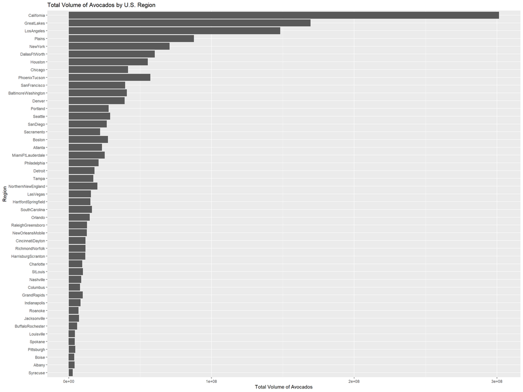

```r
#let's do some plot, plot total volume by region, we can do this two ways, #1 is to sum totalvolume by region, #2 is to do barplot or histogram
#option 2, I will use barplot using ggplots
# there is bit of a problem with size, with 47 region, the total volume scale on the Y axis need to be adjusted
# reorder seems not to be working great, ex: chicago comes before PhoenixTuscon
avocados2015a %>%
  ggplot(aes(x=forcats::fct_reorder(region,Total.Volume ), y = Total.Volume )) +
  geom_col() +
  coord_flip() +
  labs(x="Region", y="Total Volume of Avocados", title = "Total Volume of Avocados by U.S. Region")
```

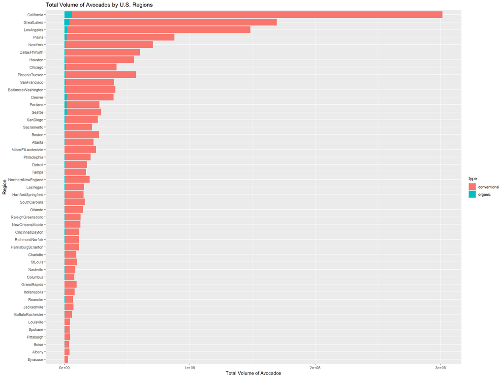

```r
# now let's add the two type ..conventional and organic
avocados2015a %>%
  ggplot(aes(x=forcats::fct_reorder(region,Total.Volume ), y = Total.Volume , fill = type)) +
  geom_col() +
  coord_flip() +
  labs(x="Region", y="Total Volume of Avocados", title = "Total Volume of Avocados by U.S. Regions")
```